# STOR 320 Tutorial on Programming 1

October 13, 2025

# Introduction

In this tutorial, we will try to understand some fundamental control structures used in statistical programming. In the beginning, we will separately analyze different control structures.

- `if` and `else`: testing a condition and acting on it
- `for`: execute a loop a fixed number of times
- `while`: execute a loop while a condition is true

# Part 1: *If-Else* Statements

General Construction:

- `if`:

```r
if (CONDITION) {
    ACTION
}
```

- `if else`:

```r
if (CONDITION) {
    ACTION 1
} else {
    ACTION 2
}
```

- `ifelse()`:

```r
ifelse(CONDITION,ACTION1,ACTION2)
```

## Chunk 1: Illustration of *If*

```r
x = 3
if(x > 0){
  print(log(x))
}

x = -3
if(x > 0){
  print(log(x))
}
```

## Chunk 2: Illustration of *If-Else*

```r
x = 3
if(x > 0){
  print(log(x))
} else{
  message("Unable to Take Logarithm")
}

x = -3
if(x > 0){
  print(log(x))
} else {
  message("Unable to Take Logarithm")
}
```

### Excercise 1

Write code that takes numbers `a` and `b` as input and prints ‘a is greater than b’ if `a>b`, otherwise prints ‘a is not greater than b’.

```r
a = 10
b = 8
# write code here
if (a>b){
  print('a is greater than b')
} else {
  print('a is not greater than b')
}
```

```
## [1] "a is greater than b"
```

## Chunk 3: Potential Problem of *If-Else* Statements

Question: The following code will fail when `x` equals to what?

```r
x = 'one'
if(x > 0){
  print(log(x))
}

if(x > 0){
  print(log(x))
} else{
  message("Unable to Take Logarithm")
}
```

## Chunk 4: Fixing Potential Problem in Chunk 3

Question: What do you think we can do to get rid of the problem?

```r
x='one'
if(is.numeric(x)){
  if(x > 0){
    print(log(x))
  } else{
    message("Unable to Take Logarithm")
  }
} else{
  message("Please Input Numbers")
}
```

### Excercise 2

Redo Excercise 1 but check the data types before doing the comparison. Hint: `&&` (and) and `||` (or) can be used to combine multiple logical expressions. Please don’t use `&` and `|` in an `if` statement: these are vectorized operations.

```r
a = '10'
b = 8
if(is.numeric(a)&&is.numeric(b)){
  if (a>b){
    print('a is greater than b')
  } else {
    print('a is not greater than b')
  }
} else{
  message("Please Input Numbers")
}
```

```
## Please Input Numbers
```

## Chunk 5: Vectorized Version with `ifelse()`

### Chunk 5.A

```r
x=c(-1,3,200)
print(log(x))

y1 =  try(if(x > 0){
        log(x)
      } else{
        NA
      }, silent=T)
print(y1)
```

### Chunk 5.B

```r
x <- c(-1, 3, 200)

# Option 1: only the one element
y1_first <- if (x[1] > 0) { log(x) } else { NA }
print(y1_first)

# Option 2: reduce the vector to a single TRUE/FALSE with any()/all()
y1_any <- if (any(x > 0)) { "At least one positive" } else { "No positives" }
y1_all <- if (all(x > 0)) { "All positive" } else { "Not all positive" }
print(y1_any); print(y1_all)
```

### Chunk 5.C

```r
y2 = ifelse(x>0,log(x),NA)
print(y2)
```

## Chunk 6: Nested `ifelse()` Statements

```r
x=rnorm(1000,mean=0,sd=1)
y=ifelse(abs(x)<1,"Within 1 SD",
         ifelse(abs(x)>2,"Far Far Away",
                "Between 1 and 2 SD"))

y.fct=factor(y,levels=c("Within 1 SD","Between 1 and 2 SD","Far Far Away"))
ggplot() +
  geom_bar(aes(x=y.fct),fill="lightskyblue1") +
  theme_minimal()
```

### Excercise 3

Please use `ifelse()` function to create a new column `WageLevel` with `lwage` column of the `Wages` dataset from `Ecdat`.

- If the `lwage` is greater than $7.0$, the corresponding value in the final vector is `High Wage`.
- If `lwage` is lower than $6.4$, the value is `Low Wage`.
- For all the other cases, the values are `Normal`.

```r
New_Wages = Wages %>%
  mutate(WageLevel=ifelse(lwage>7.0,'High Wage',
                          ifelse(lwage<6.4, 'Low Wage', 'Normal')
                          )
         )
head(New_Wages,5)
```

```
##   exp wks bluecol ind south smsa married  sex union ed black   lwage WageLevel
## 1   3  32      no   0   yes   no     yes male    no  9    no 5.56068  Low Wage
## 2   4  43      no   0   yes   no     yes male    no  9    no 5.72031  Low Wage
## 3   5  40      no   0   yes   no     yes male    no  9    no 5.99645  Low Wage
## 4   6  39      no   0   yes   no     yes male    no  9    no 5.99645  Low Wage
## 5   7  42      no   1   yes   no     yes male    no  9    no 6.06146  Low Wage
```

# Part 2: Loops

## Chunk 1: Checking Geometric Series Proof with *for* loop

Geometric Series: $a, ar, ar^2, ar^3,...$

Formula of Sum: $\sum_{k=0}^\infty ar^k=\frac{a}{1-r}$, for $|r|<1$.

```r
a=2 #Any Number
r=0.5 #Any Number Between -1 and 1: abs(r)<1

theoretical.limit=a/(1-r)

START=a

FINISH.1 = START + a*r^1

FINISH.2 = FINISH.1 + a*r^2

FINISH.3 = FINISH.2 + a*r^3

# Notice the repeated pattern above: FINISH.k = FINISH.(k-1) + a*r^k
###---------------------------------------------###
FINISH.10 = a
for(k in 1:10){
  FINISH.10=FINISH.10+a*r^k
}

FINISH.100 = a
for(k in 1:100){
  FINISH.100=FINISH.100+a*r^k
}

DATA = tibble(k=c(1,2,3,10,100,"Infinity"),
            SUMMATION=c(FINISH.1,FINISH.2,FINISH.3,
                        FINISH.10,FINISH.100,
                        theoretical.limit))
print(DATA)

ABSOLUTE.ERROR = abs(FINISH.100-theoretical.limit)
print(ABSOLUTE.ERROR)
```

### Excercise 4

```r
set.seed(4)
u = rnorm(100)
```

Use `for` loop to calculate sum of the squares of the first 10 elements of vector `u`. Hint: `^` (Exponents), `3^2=9`

```r
sum10 = 0
for(i in 1:10){
  sum10 = sum10 + u[i]^2
}
print(sum10)
```

```
## [1] 13.08209
```

Use `for` loop and `if` statement to calculate the sum of squares of the elements with even indices of vector `u`. Hint: `%%` gives the remainder of division.

```r
sum_even = 0
for(i in 1:100){
  if (i%%2 ==0){
    sum_even = sum_even + u[i]^2
  }
}
print(sum_even)
```

```
## [1] 37.33534
```

```r
sum_even = 0
for(i in seq(2,100,2)){
  sum_even = sum_even + u[i]^2
}
print(sum_even)
```

```
## [1] 37.33534
```

## Chunk 2: Checking Geometric Series Proof with *while* loop

```r
while (CONDITION) {
  ACTION
}
```

```r
a=2
r=0.5

FINISH=a
k=0
while(abs(FINISH-a/(1-r)) > 1e-10) {
  k=k+1
  FINISH = FINISH + a*r^k
  #if(k>100) break
}
print(c(k,FINISH))
```

## Chunk 3: Saving Steps in Geometric Series for Figure

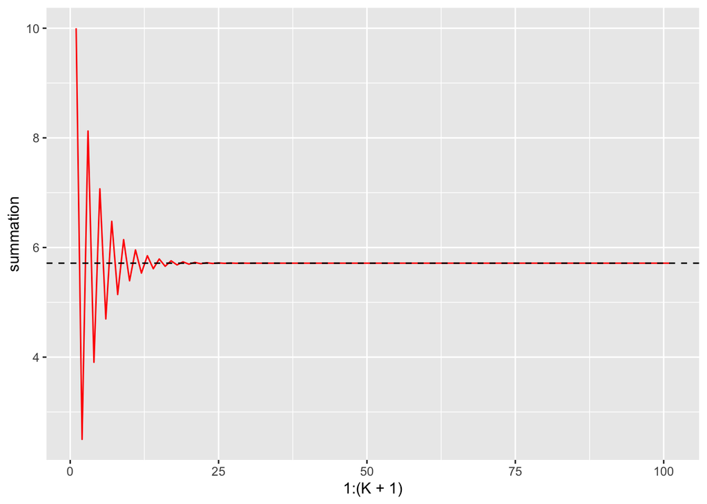

```r
a=10
r=-0.75
theoretical.limit=a/(1-r)

K=100 #How Many Steps Do You Want to Save?

summation=rep(NA,(K+1))
summation[1]=a
for (k in 1:K) {
  summation[k+1]=summation[k] + a*r^k
}

ggplot() +
  geom_line(aes(x=1:(K+1),y=summation),color='red') +
  geom_hline(yintercept=theoretical.limit,
             linetype="dashed")
```

### Excercise 5

Write `for` loops to generate 100 random samples from normal distributions with means of 0 to 99 and save the random samples to a vector `a`.

- The `k`th component of `a` is generated from $N(k-1,1)$.
- Hint: Function for generating random samples from normal distribution `rnorm`.

```r
set.seed(100)
a = rep(NA,100)
for (k in 1:100){
  a[k] = rnorm(1,k-1,1)
}
print(a)
```

```
##   [1] -0.5021924  1.1315312  1.9210829  3.8867848  4.1169713  5.3186301
##   [7]  5.4182093  7.7145327  7.1747406  8.6401379 10.0898861 11.0962745
##  [13] 11.7983660 13.7398405 14.1233795 14.9706833 15.6111458 17.5108563
##  [19] 17.0861858 21.3102968 19.5619100 21.7640606 22.2619613 23.7734046
##  [25] 23.1856209 24.5615494 25.2797784 27.2309445 26.8422705 29.2470760
##  [31] 29.9088864 32.7573756 31.8620704 32.8888065 33.3099857 34.7782058
##  [37] 36.1829077 37.4173233 39.0654023 39.9702020 39.8983708 42.4032035
##  [43] 40.2232244 43.6228674 43.4777166 46.3222310 45.6365597 48.3190657
##  [49] 48.0437791 47.1213441 49.5529378 49.2614021 52.1788648 54.8974657
##  [55] 51.7280745 55.9804641 54.6011744 58.8248724 59.3812987 58.1611481
##  [61] 59.7380042 60.9311560 61.6211164 65.5819589 64.1298341 64.2869750
##  [67] 66.6379942 67.2016916 67.9300831 68.9075101 70.4489033 69.9356443
##  [73] 70.8375807 74.6485217 71.9379040 75.0127497 74.9124717 77.2705395
##  [79] 79.0084519 76.9255952 80.8968223 80.9500042 80.6546507 81.0687885
##  [85] 84.7095816 84.8420950 86.2163679 87.8173621 89.7271758 88.8962297
##  [91] 89.4428777 92.4283014 91.1070426 91.8424288 93.4697035 97.4456828
##  [97] 95.1675042 97.4135198 96.8213169 97.8259652
```